# Projet STA101

## a.Test de Shapiro-wilk

Nous décidons de réaliser des tests de Shapiro-wilk pour voir la distribution au sein de chaque variable.

Lorsque la p-value est supérieur à 0,05 on conserve l’hypothèse HO, l’échantillon suit une loi normale.  
Par contre lorque la p_value est inférieur à 0,05, on rejette l’hypothèse HO, l’echantillon ne suit pas une loi normale.

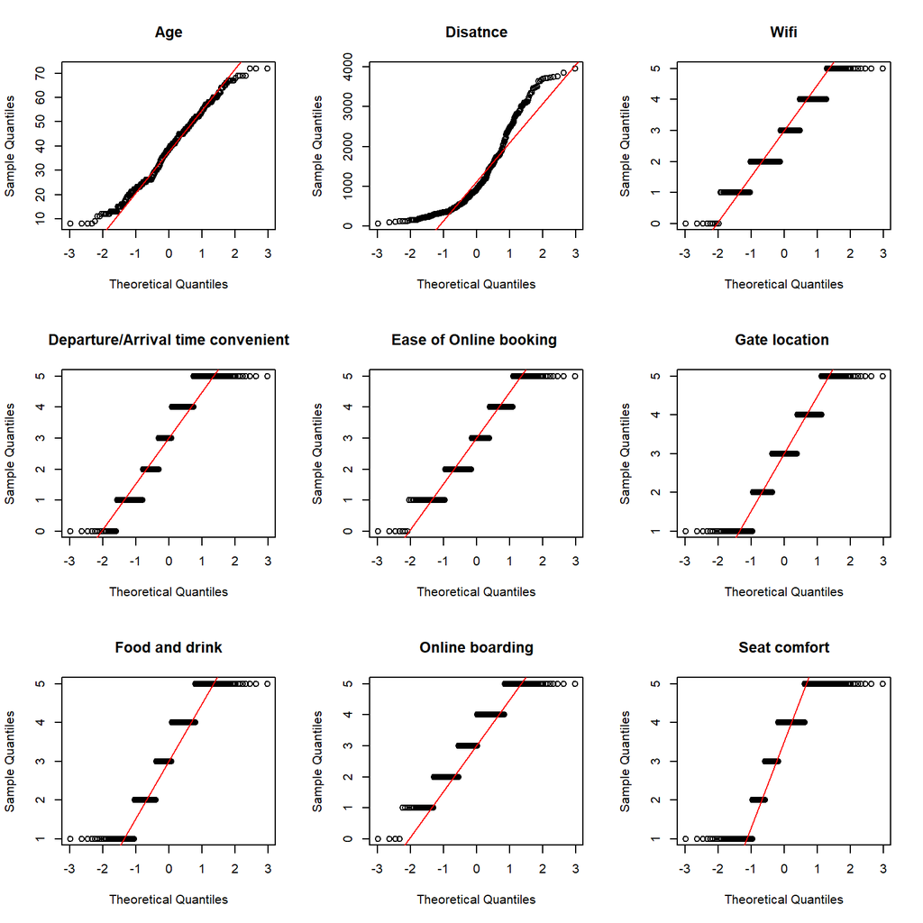

```r
# Partition en 3 lignes et 3 colonnes
par(mfrow = c(3,3))
qqnorm(df$Age, main = "Age")
qqline(df$Age,col = "red")

qqnorm(df$Distance,main = "Disatnce")
qqline(df$Distance,col = "red")

qqnorm(df$wifi,main = "Wifi")
qqline(df$wifi,col = "red")

qqnorm(df$HeureConvenableDA, main = "Departure/Arrival time convenient")
qqline(df$HeureConvenableDA,col = "red")

qqnorm(df$ReserFacil,main = "Ease of Online booking ")
qqline(df$ReserFacil,col = "red")

qqnorm(df$Emplacement,main = "Gate location ")
qqline(df$Emplacement,col = "red")

qqnorm(df$alimentation,main = "Food and drink")
qqline(df$alimentation,col = "red")

qqnorm(df$EmbarqEnLign,main = "Online boarding")
qqline(df$EmbarqEnLign,col = "red")

qqnorm(df$confortSiege,main = "Seat comfort")
qqline(df$confortSiege,col = "red")
```

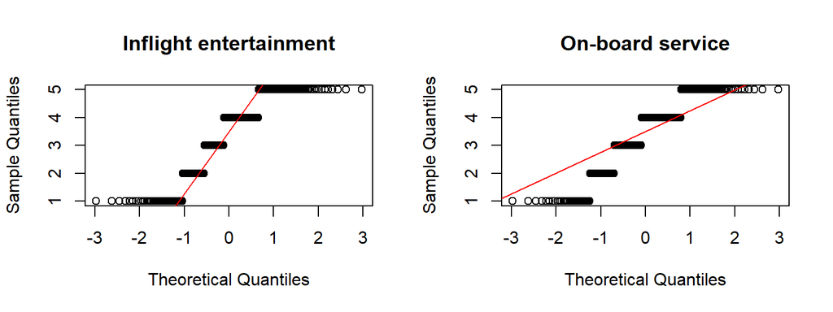

```r
# Partition en 3 lignes et 3 colonnes
par(mfrow = c(1,2))
qqnorm(df$Divertissements,main = "Inflight entertainment")
qqline(df$Divertissements,col = "red")

qqnorm(df$ServiceABord,main = "On-board service")
qqline(df$ServiceABord,col = "red")
```

```r
shapiro.test(df$Age)
```

```
##
##  Shapiro-Wilk normality test
##
## data:  df$Age
## W = 0.98098, p-value = 0.0001475
```

```r
shapiro.test(df$Distance)
```

```
##
##  Shapiro-Wilk normality test
##
## data:  df$Distance
## W = 0.88214, p-value = 1.081e-15
```

```r
shapiro.test(df$wifi)
```

```
##
##  Shapiro-Wilk normality test
##
## data:  df$wifi
## W = 0.92932, p-value = 8.912e-12
```

```r
shapiro.test(df$HeureConvenableDA)
```

```
##
##  Shapiro-Wilk normality test
##
## data:  df$HeureConvenableDA
## W = 0.89949, p-value = 2.092e-14
```

```r
shapiro.test(df$ReserFacil)
```

```
##
##  Shapiro-Wilk normality test
##
## data:  df$ReserFacil
## W = 0.9234, p-value = 2.374e-12
```

```r
shapiro.test(df$Emplacement)
```

```
##
##  Shapiro-Wilk normality test
##
## data:  df$Emplacement
## W = 0.90876, p-value = 1.181e-13
```

```r
shapiro.test(df$alimentation)
```

```
##
##  Shapiro-Wilk normality test
##
## data:  df$alimentation
## W = 0.89068, p-value = 4.453e-15
```

```r
shapiro.test(df$EmbarqEnLign)
```

```
##
##  Shapiro-Wilk normality test
##
## data:  df$EmbarqEnLign
## W = 0.90937, p-value = 1.33e-13
```

```r
shapiro.test(df$confortSiege)
```

```
##
##  Shapiro-Wilk normality test
##
## data:  df$confortSiege
## W = 0.85417, p-value < 2.2e-16
```

```r
shapiro.test(df$Divertissements)
```

```
##
##  Shapiro-Wilk normality test
##
## data:  df$Divertissements
## W = 0.87046, p-value < 2.2e-16
```

```r
shapiro.test(df$ServiceABord)
```

```
##
##  Shapiro-Wilk normality test
##
## data:  df$ServiceABord
## W = 0.88943, p-value = 3.604e-15
```

```r
shapiro.test(df$ConfortJambes)
```

```
##
##  Shapiro-Wilk normality test
##
## data:  df$ConfortJambes
## W = 0.88096, p-value = 8.937e-16
```

```r
shapiro.test(df$ServiceBagages)
```

```
##
##  Shapiro-Wilk normality test
##
## data:  df$ServiceBagages
## W = 0.87658, p-value = 4.471e-16
```

```r
shapiro.test(df$ServiceEnregitrm)
```

```
##
##  Shapiro-Wilk normality test
##
## data:  df$ServiceEnregitrm
## W = 0.89187, p-value = 5.459e-15
```

```r
shapiro.test((df$ServiceEnVol))
```

```
##
##  Shapiro-Wilk normality test
##
## data:  (df$ServiceEnVol)
## W = 0.86781, p-value < 2.2e-16
```

```r
shapiro.test(df$Proprete)
```

```
##
##  Shapiro-Wilk normality test
##
## data:  df$Proprete
## W = 0.89047, p-value = 4.303e-15
```

```r
shapiro.test(df$MinutesRetardDepart)
```

```
##
##  Shapiro-Wilk normality test
##
## data:  df$MinutesRetardDepart
## W = 0.52556, p-value < 2.2e-16
```

```r
shapiro.test(df$MinutesRetardArrivee)
```

```
##
##  Shapiro-Wilk normality test
##
## data:  df$MinutesRetardArrivee
## W = 0.50864, p-value < 2.2e-16
```

Les 18 variables quantitatives ont des p-valeurs inférieures à 0,05, donc elles ne suivent pas la loi normale.